# Machine Learning - Final Test

Alberto Rossi

16/06/2020

# Overview

Using devices such as Jawbone Up, Nike FuelBand, and Fitbit it is now possible to collect a large amount of data about personal activity relatively inexpensively. These type of devices are part of the quantified self movement – a group of enthusiasts who take measurements about themselves regularly to improve their health, to find patterns in their behavior, or because they are tech geeks. One thing that people regularly do is quantify how much of a particular activity they do, but they rarely quantify how well they do it.

In this project, your goal will be to use data from accelerometers on the belt, forearm, arm, and dumbell of 6 participants.

They were asked to perform barbell lifts correctly and incorrectly in 5 different ways. More information is available from the website here: http://groupware.les.inf.puc-rio.br/har (see the section on the Weight Lifting Exercise Dataset).

# Objective

The goal of your project is to predict the manner in which they did the exercise. This is the “classe” variable in the training set. You may use any of the other variables to predict with.

You should create a report describing how you built your model, how you used cross validation, what you think the expected out of sample error is, and why you made the choices you did. You will also use your prediction model to predict 20 different test cases.

# Data loading and preparing

Reading of data according to informed URLs and loading of files in data frames.

Once this is done, some data (NearZero, NAs) and some columns that bring irrelevant information to the analysis are cleaned up.

This step is critical to the downsizing of the data and better performance execution analysis.

```r
  library(caret)
```

```r
  #Reading and confirming data
  fnameTraining <- "pml-training.csv"
  fnameTesting <- "pml-testing.csv"

  fileURLTraining <- "https://d396qusza40orc.cloudfront.net/predmachlearn/pml-training.csv"
  fileURLTest <- "https://d396qusza40orc.cloudfront.net/predmachlearn/pml-testing.csv"

  # File already exists?
  if (!file.exists(fnameTraining)){
    download.file(url = fileURLTraining,
                  destfile = fnameTraining)
  }

  # File already exists?
  if (!file.exists(fnameTesting)){
    download.file(url = fileURLTest,
                  destfile = fnameTesting)
  }

  # Data read
  trainingData <- read.table(fnameTraining,
                             sep = ",",
                             dec = ".",
                             header = TRUE,
                             na.strings = "NA")

  validationData <- read.table(fnameTesting,
                             sep = ",",
                             dec = ".",
                             header = TRUE,
                             na.strings = "NA")

  # Checking datasets

  str(trainingData)
```

```
## 'data.frame':    19622 obs. of  160 variables:
##  $ X                       : int  1 2 3 4 5 6 7 8 9 10 ...
##  $ user_name               : chr  "carlitos" "carlitos" "carlitos" "carlitos" ...
##  $ raw_timestamp_part_1    : int  1323084231 1323084231 1323084231 1323084232 1323084232 1323084232 1323084232 1323084232 1323084232 1323084232 ...
##  $ raw_timestamp_part_2    : int  788290 808298 820366 120339 196328 304277 368296 440390 484323 484434 ...
##  $ cvtd_timestamp          : chr  "05/12/2011 11:23" "05/12/2011 11:23" "05/12/2011 11:23" "05/12/2011 11:23" ...
##  $ new_window              : chr  "no" "no" "no" "no" ...
##  $ num_window              : int  11 11 11 12 12 12 12 12 12 12 ...
##  $ roll_belt               : num  1.41 1.41 1.42 1.48 1.48 1.45 1.42 1.42 1.43 1.45 ...
##  $ pitch_belt              : num  8.07 8.07 8.07 8.05 8.07 8.06 8.09 8.13 8.16 8.17 ...
##  $ yaw_belt                : num  -94.4 -94.4 -94.4 -94.4 -94.4 -94.4 -94.4 -94.4 -94.4 -94.4 ...
##  $ total_accel_belt        : int  3 3 3 3 3 3 3 3 3 3 ...
##  $ kurtosis_roll_belt      : chr  "" "" "" "" ...
##  $ kurtosis_picth_belt     : chr  "" "" "" "" ...
##  $ kurtosis_yaw_belt       : chr  "" "" "" "" ...
```

[output cut: 86 more lines]

```r
  str(validationData)
```

```
## 'data.frame':    20 obs. of  160 variables:
##  $ X                       : int  1 2 3 4 5 6 7 8 9 10 ...
##  $ user_name               : chr  "pedro" "jeremy" "jeremy" "adelmo" ...
##  $ raw_timestamp_part_1    : int  1323095002 1322673067 1322673075 1322832789 1322489635 1322673149 1322673128 1322673076 1323084240 1322837822 ...
##  $ raw_timestamp_part_2    : int  868349 778725 342967 560311 814776 510661 766645 54671 916313 384285 ...
##  $ cvtd_timestamp          : chr  "05/12/2011 14:23" "30/11/2011 17:11" "30/11/2011 17:11" "02/12/2011 13:33" ...
##  $ new_window              : chr  "no" "no" "no" "no" ...
##  $ num_window              : int  74 431 439 194 235 504 485 440 323 664 ...
##  $ roll_belt               : num  123 1.02 0.87 125 1.35 -5.92 1.2 0.43 0.93 114 ...
##  $ pitch_belt              : num  27 4.87 1.82 -41.6 3.33 1.59 4.44 4.15 6.72 22.4 ...
##  $ yaw_belt                : num  -4.75 -88.9 -88.5 162 -88.6 -87.7 -87.3 -88.5 -93.7 -13.1 ...
##  $ total_accel_belt        : int  20 4 5 17 3 4 4 4 4 18 ...
##  $ kurtosis_roll_belt      : logi  NA NA NA NA NA NA ...
##  $ kurtosis_picth_belt     : logi  NA NA NA NA NA NA ...
##  $ kurtosis_yaw_belt       : logi  NA NA NA NA NA NA ...
```

[output cut: 86 more lines]

```r
  # Cleaning: Near Zero Variance variables from datasets
  nzv <- nearZeroVar(trainingData, saveMetrics = T)
  trainingData <- trainingData[, !nzv$nzv]
  validationData <- validationData[, !nzv$nzv]

  # Cleaning: Remove columns that contain NA's
  nas <- (colSums(is.na(trainingData)) == 0)
  trainingData <- trainingData[, nas]
  validationData <- validationData[, nas]

  # Cleaning: remove 1 to 5 columns from datasets (useless)
  trainingData <- trainingData[ , -c(1:5)]
  validationData <- validationData[ , -c(1:5)]
```

# Data partition

We will partition the data according to the rule below:

```r
  set.seed(1609)
  partitionIndex <- createDataPartition(y=trainingData$classe, p=0.6, list=FALSE)
  trainingData <- trainingData[partitionIndex, ]
  testingData <- trainingData[-partitionIndex, ]
```

# Prediction models selection

- Random forest decision trees (rf)
- Stochastic gradient boosting trees (gbm)
- Linear Discriminant Analysis (lda)

```r
  # Training our data


  load(file = "C:/RStudio/datasciencecoursera/Modelrf.RData")
  #model_rf <- train(classe ~ .,
  #                   data=trainingData,
  #                  method='rf')
  #save(model_rf, file="./Modelrf.RData")

  load(file = "C:/RStudio/datasciencecoursera/Modelgbm.RData")
  #model_gbm <- train(classe ~ .,
  #                   data=trainingData,
  #                   method='gbm')
  #save(model_gbm, file="./Modelgbm.RData")

  load(file = "C:/RStudio/datasciencecoursera/Modelda.RData")
  #model_lda <- train(classe ~ .,
  #                  data=trainingData,
  #                  method='lda')
  #save(model_lda, file="./Modelda.RData")
```

# Model analysis

```r
  # Run RF model
  predmodel_rf <- predict(model_rf, newdata=testingData)
  cmmodel_rf <- confusionMatrix(table(predmodel_rf, testingData$classe))

  # Run GBM model
  predmodel_gbm <- predict(model_gbm, newdata=testingData)
  cmmodel_gbm <- confusionMatrix(table(predmodel_gbm, testingData$classe))

  # Run LDA model
  predmodel_lda <- predict(model_lda, newdata=testingData)
  cmmodel_lda <- confusionMatrix(table(predmodel_lda, testingData$classe))

  accuracyTable <- data.frame(Model = c('RF', 'GBM', 'LDA'),
                              Accuracy = rbind(cmmodel_rf$overall[1],
                                               cmmodel_gbm$overall[1],
                                               cmmodel_lda$overall[1]))

  print(accuracyTable)
```

```
##   Model Accuracy
## 1    RF 1.000000
## 2   GBM 0.993386
## 3   LDA 0.719010
```

# Model Prediction

The best model is choosen to predict values from Validation dataset, with 20 observations. In this case, RF:

```r
  predData <- predict(model_rf, newdata=validationData)
  PredResults <- data.frame(problem_id=validationData$problem_id,
                                            predicted=predData)
  print(PredResults)
```

```
##    problem_id predicted
## 1           1         B
## 2           2         A
## 3           3         B
## 4           4         A
## 5           5         A
## 6           6         E
## 7           7         D
## 8           8         B
## 9           9         A
## 10         10         A
## 11         11         B
## 12         12         C
## 13         13         B
## 14         14         A
## 15         15         E
## 16         16         E
## 17         17         A
## 18         18         B
## 19         19         B
## 20         20         B
```

# Conclusion

The Random Forest model delivers the best analysis accuracy for the data in question.

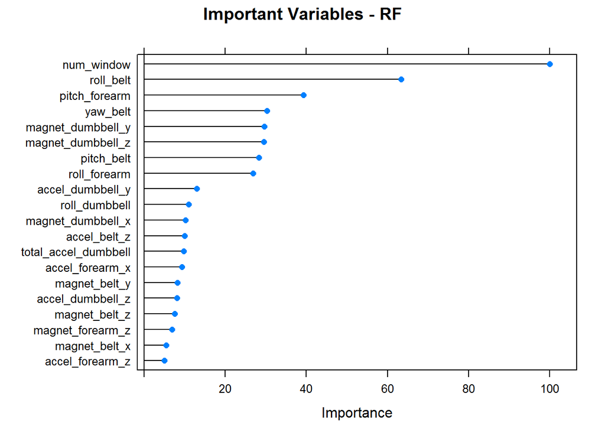

```r
  varImpObj <- varImp(model_rf)
  plot(varImpObj, main = "Important Variables - RF", top = 20)
```